# Analyzing TF Networks

Paul M. Magwene

March 9, 2017

## Load packages

```r
library(dplyr)
library(tidyr)
library(ggplot2)
```

## Load and explore the Lee et al. data

```r
lee <- read.csv("lee-etal-data.csv")
```

Data frame dimensions

```r
dim(lee)
```

Column (variable) names

```r
names(lee)[1:15] # first 15 column names
```

Take a look at the first few rows and columns:

```r
lee[1:5, 1:8] # first 5 rows, first 8 columns
```

Look at data for one variable:

```r
lee$MATA1[1:15]  # first 15 elements
```

These entries give p-values for the binding interactions between the TF of interest (MATA1) and the corresponding genes. The smaller the p-value, the stronger the evidence that the TF of interest binds to the promoter region of a given gene. “NaN” entries indicate missing data.

## Create a modified version of the data frame

Let’s create a modified version of data frame, dropping the `Common.Name` and `Annotation` variables, and renaming the `Name` variable to `target`.

```r
lee.tfs <- lee %>%
  dplyr::select(-Common.Name, -Annotation) %>%
  dplyr::rename(target = Name)
```

Now, let’s create a “long” version of the data frame, which will be convenient for filtering and exploration:

```r
lee.tfs.long <- lee.tfs %>%
  tidyr::gather(TF, pvalue, -target) %>% # cast to long format
  dplyr::select(TF, target, pvalue) # reorder columns
```

Let’s see what our long format data frame looks like:

```r
head(lee.tfs.long)
```

## Finding targets of a given TF

- How you would find all the targets of a given TF? Let’s look at the data for one TF.

```r
lee.tfs.long %>%
  filter(TF == "MATA1") %>%
  head()
```

We want to filter out all edges below a certain p-value (Lee et al. used p = 0.001 as cutoff) as well as “NA” entries. Adding an additional predicate to our `filter` call will take care of this:

```r
MATA1.bound <-
  lee.tfs.long %>%
  filter(TF == "MATA1" & pvalue < 0.001)

MATA1.bound
```

If we wanted the targets as strings

```r
as.character(MATA1.bound$target)
```

## Reduced data frame

Let’s consider only those TF-gene interactions with p-values less than 0.001

```r
lee.trimmed <- filter(lee.tfs.long, pvalue < 0.001)
```

We’ve already seen how to get all the genes whose promoter regions are bound by a particular transcription fact:

```r
# find all the genes bound by RIM101
lee.trimmed %>% filter(TF == "RIM101")
```

You can similarly use a filter to find all the TFs that bind to the promoter of a particular gene:

```r
# find all the TFs that bind YAL022C
lee.trimmed %>% filter(target =="YAL022C")
```

## Creating a histogram showing the number of genes bound

Find the number of genes bound per TF

```r
hits.per.tf <- lee.trimmed %>%
               group_by(TF) %>%
               summarise(ngenes = length(target))

hits.per.tf
```

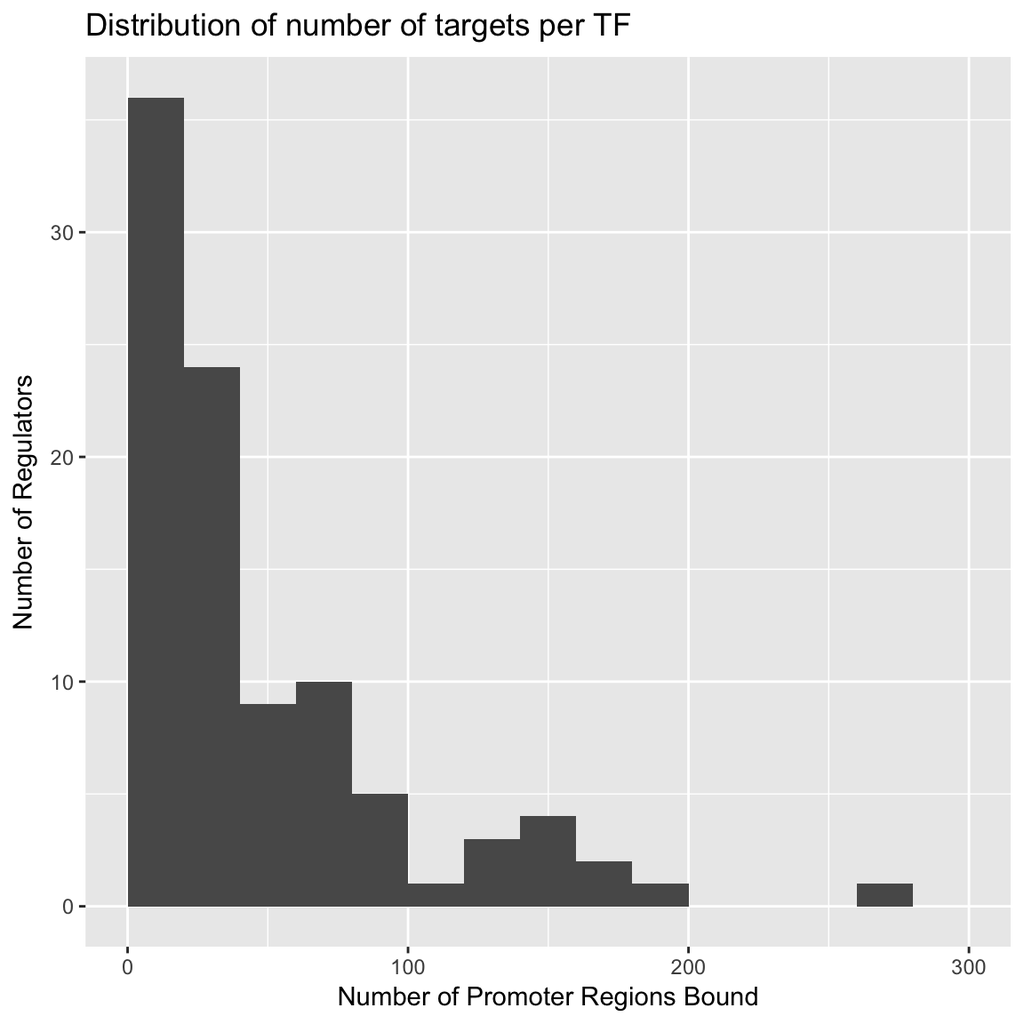

```r
qplot(hits.per.tf$ngenes, breaks=seq(0,300,20), geom = "histogram",
     xlab="Number of Promoter Regions Bound",
     ylab="Number of Regulators",
     main="Distribution of number of targets per TF")
```

What is the distribution of the number of TFs that each gene is regulated by?

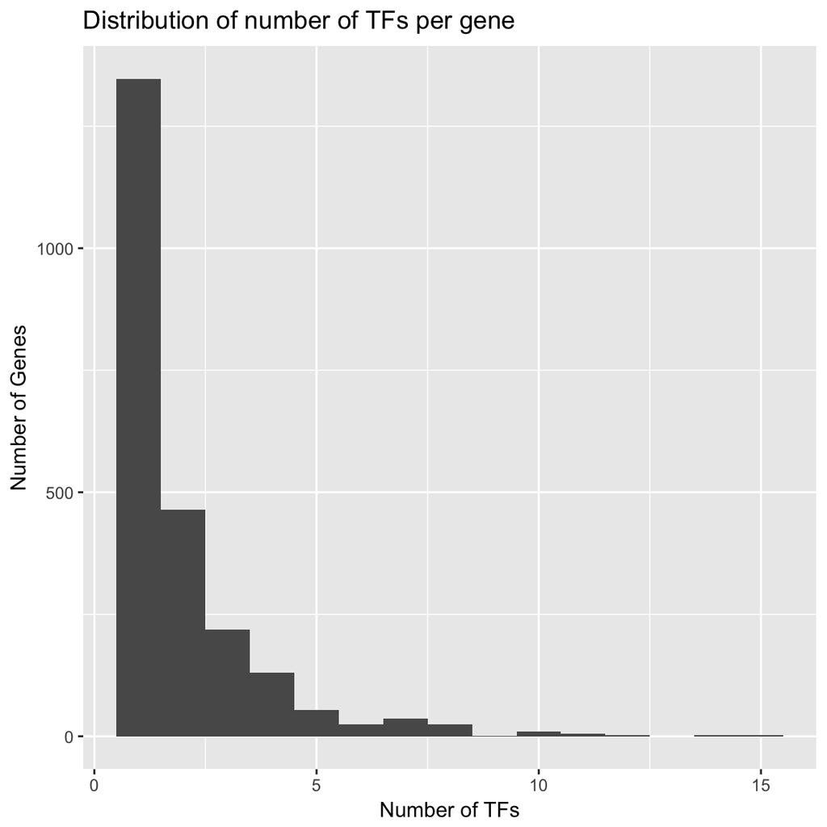

```r
tfs.per.gene <- lee.trimmed %>%
                group_by(target) %>%
                summarise(ntfs = length(TF))


ggplot(tfs.per.gene, aes(x = ntfs)) +
  geom_histogram(binwidth = 1) +
  labs(x = "Number of TFs", y = "Number of Genes",
       title = "Distribution of number of TFs per gene")
```

## Install some new packages

- Install igraph

```r
install.packages("igraph", dependencies = TRUE)
```

```r
library(igraph)
```

## Creating a graph from a data frame

```r
lee.graph <- graph_from_data_frame(lee.trimmed)
```

`igraph::vcount` gives the number of vertices in the graph:

```r
vcount(lee.graph)
```

`igraph::ecount` gives the number of edges

```r
ecount(lee.graph)
```

`igraph::V` returns the vertices of the graph:

```r
V(lee.graph)
```

`igraph::E` gives the edges:

```r
E(lee.graph)
```

## Specify bipartite structure of graph

Our network has two classes of nodes – transcription factors (TFs) and the genes they regulate. In our current representation edges are only between TFs and genes, never directly between TFs or between genes. A network of this type is called a “bipartite graph”.

To tell `igraph` functions that we’re working with a bipartite graph, we need to set the `type` attribute of each vertex. We’ll use TRUE to indicate a vertex is a transcription factor, and FALSE to indicate a vertex is a gene.

```r
tfs <- unique(lee.trimmed$TF)  # get vector of TF neames

# for each vertex in the graph, set it's type to TRUE or FALSE
# depending on whether the vertex represents a TF or a gene
V(lee.graph)$type <- V(lee.graph)$name %in% tfs
```

For the purpose of making nice figures, we’ll also set some shape and color attributes for each vertex based on the `type` attribute. We’ll use pinkish-red circles to represent TFs and blue square to represent genes.

```r
V(lee.graph)$shape  <- c("square", "circle")[V(lee.graph)$type+1]
V(lee.graph)$color  <- c("steelblue", "lightcoral")[V(lee.graph)$type+1]
```

## Vertex degree

Get degree of particular vertices:

```r
degree(lee.graph, "MATA1")
degree(lee.graph, "STE12")
```

`degree` can take more than one vertex name

```r
degree(lee.graph, c("STE12", "DIG1"))
```

TF degree sorted from largest to smallest:

```r
sort(degree(lee.graph, tfs), decreasing = TRUE)
```

## Connected components

How many connected components (disconnected subgraphs) are there?

```r
count_components(lee.graph)
```

Get connected components:

```r
lee.components <- decompose(lee.graph)
```

Get vertex count in each component:

```r
lapply(lee.components, vcount)
```

Get edge count in each component:

```r
lapply(lee.components, ecount)
```

Let’s plot the two smallest components:

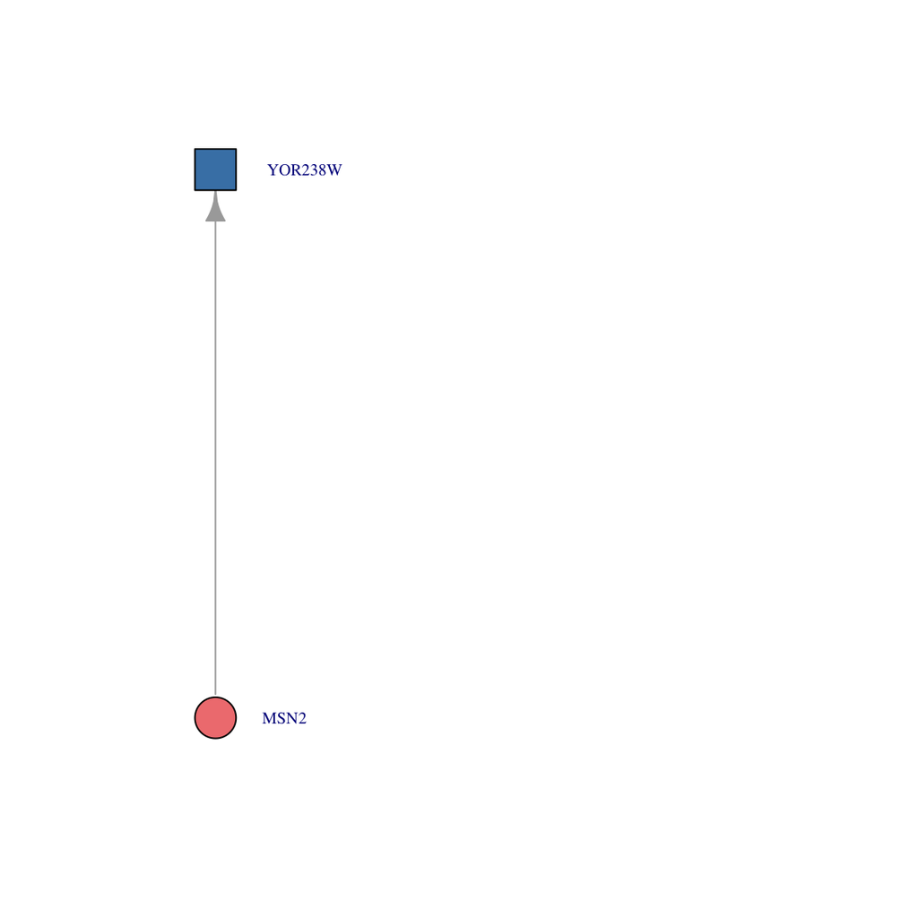

```r
plot(lee.components[[2]],
     layout = layout.bipartite,
     vertex.label.cex=0.65,
     vertex.label.degree=0, vertex.label.dist=1.5)
```

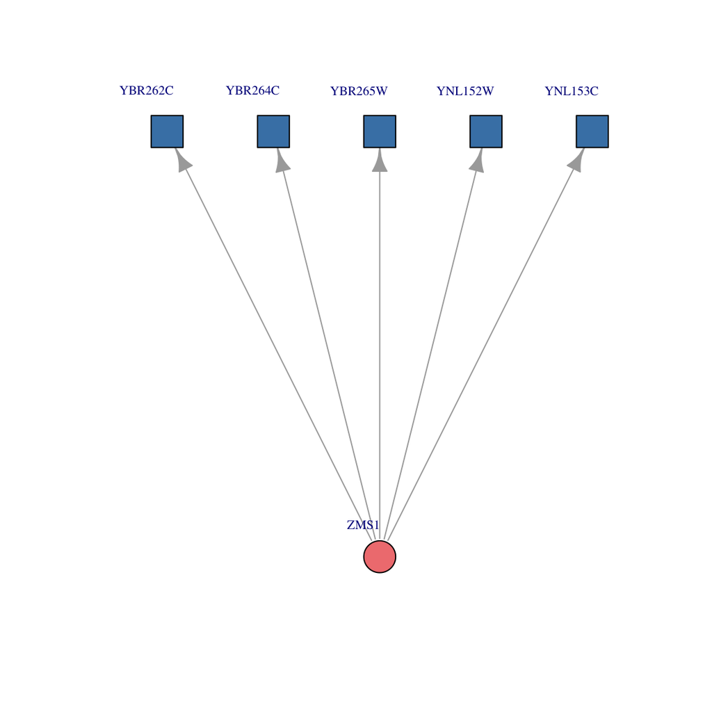

```r
plot(lee.components[[3]],
     layout = layout.bipartite,
     vertex.label.cex=0.65,
     vertex.label.degree=-90, vertex.label.dist=1)
```

We can use a short function from the igraph mailing list to find the largest connected component (https://lists.nongnu.org/archive/html/igraph-help/2009-08/msg00064.html)

```r
giant.component <- function(g, ...) {
  cl <- clusters(g, ...)
  induced_subgraph(g,  which(cl$membership == which.max(cl$csize)))
}
```

```r
big.cc <- giant.component(lee.graph)
```

## Finding neighbors of a vertex

To find all the out-neighbors (targets) of a given TF:

```r
neighbors(lee.graph, "DIG1")
```

To find all the targets in common between two TFs:

```r
intersection(neighbors(lee.graph, "DIG1"), neighbors(lee.graph, "STE12"))
```

Let’s write a function to calculate common targets between pair of TFs:

```r
targets.in.common <- function(g, name1, name2){
  targets1 <- neighbors(g, name1)
  targets2 <- neighbors(g, name2)
  common.targets <- intersection(targets1, targets2)
  return(common.targets)
}
```

You can then use this function as so:

```r
targets.in.common(lee.graph, "ABF1", "FKH1")
```

## Creating a TF-TF network based on shared targets

For bipartite graphs, $G$, where the vertex set $V$ has two subsets, $X$ and $Y$, we can define an operation called the “bipartite projection”. The bipartite projection with respect to $X$ creates a new graph, $G_X$ where $(x_i,x_j)$ is an edge if $x_i$ and $x_j$ had at least one target node, $y_i$ in common in $G$. The bipartite projection with respect to $Y$ is similarly defeined.

igraph defines a `bipartite.projection` function to compute the bipartite projection. Given a bipartite graph, `bipartite.projection` returns a list with two graphs, `proj1` and `proj2` representing the projections of the two different classes of vertices. The edges of these graphs have a `weight` attribute giving the number of target nodes in common.

We will use the bipartite projection to build two complementary network representations – 1) a network representing TFs that regulate similar sets of genes; and 2) a network representing genes that are regulated by similar sets of TFs.

```r
lee.projection <- bipartite.projection(lee.graph)
gene.proj <- lee.projection[[1]]
tf.proj <- lee.projection[[2]]
```

Now plot the graph

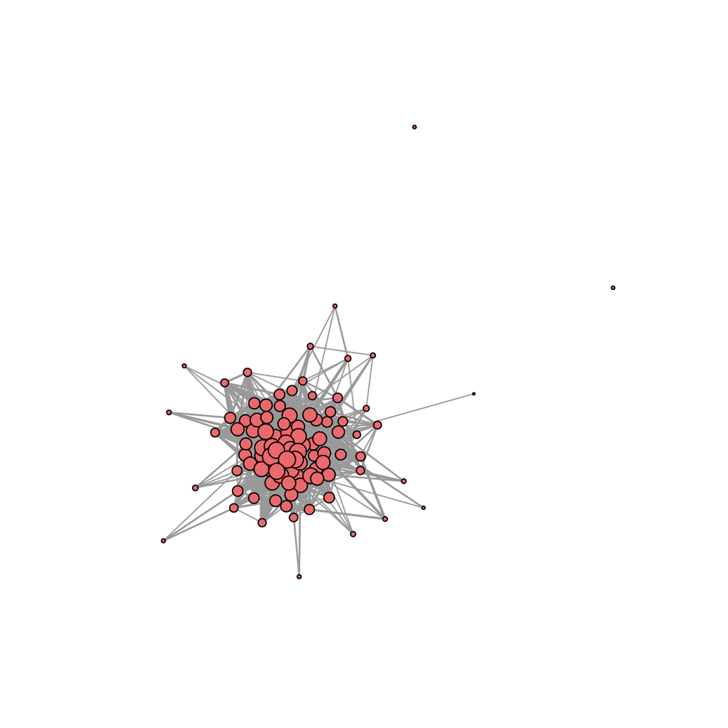

```r
V(tf.proj)$size <-sqrt(degree(tf.proj))
E(tf.proj)$width <- sqrt(E(tf.proj)$weight)

l <- layout_with_fr(tf.proj, weights=E(tf.proj)$weight)
plot(tf.proj, vertex.label=NA, layout=l)
```

That’s pretty dense as there’s lots of edges. Let’s prune some edges. We’ll create a new graph where we delete any edges with weights less than 10, meaning edges now indicate that a pair of TFs shares at least 10 target genes in common.

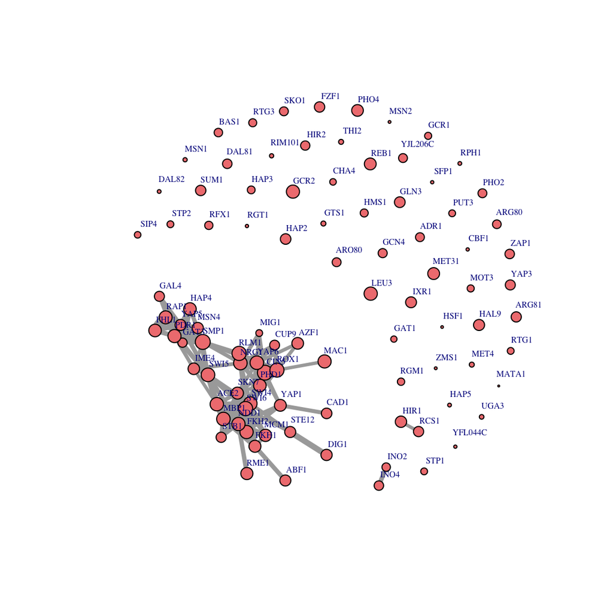

```r
tf.shared.cut <- delete.edges(tf.proj, E(tf.proj)[weight < 10])
plot(tf.shared.cut, vertex.label.cex=0.5, vertex.label.dist=0.5 )
```

Now we can use this as so

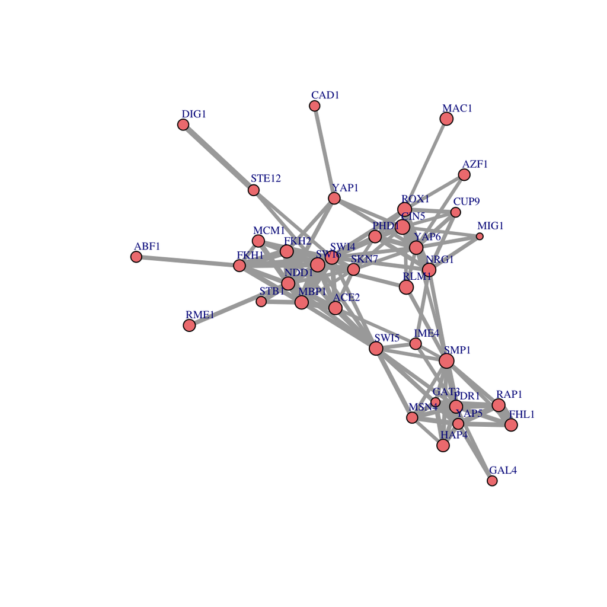

```r
big.TF.TF <- giant.component(tf.shared.cut)
E(big.TF.TF)$width <- sqrt(E(big.TF.TF)$weight)

l <- layout.fruchterman.reingold(big.TF.TF,
                                 weights=E(big.TF.TF)$weight)

plot(big.TF.TF, vertex.label.cex=0.65, vertex.label.dist=0.5,
     layout=l)
```

## Plotting networks using ggraph

There’s a new R library for generating network figures called `ggraph`. ggraph provides more powerful network plotting capabilities, and shares a similar structure to ggplot2 (upon which it is based).

- Install ggraph package

```r
install.packages("ggraph", dependencies = TRUE)
```

Once installed, load ggraph:

```r
library(ggraph)
```

Let’s plot the largest connected component of our TF-TF graph, using ggraph:

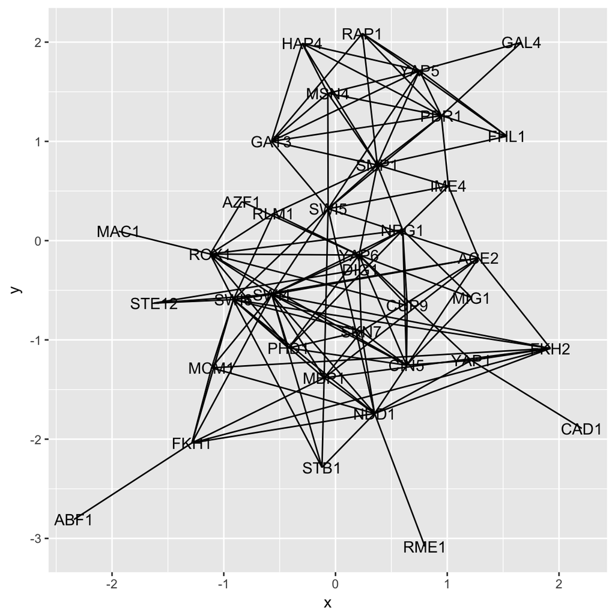

```r
ggraph(big.TF.TF, layout = "kk") +
  geom_node_text(aes(label=name)) +
  geom_edge_link()
```

We can get even fancier by changing some aspects of the plotting. Here for example we are making some changes in the aesthetic of `geom_edge_link` to prevent the edges from being drawn on top of the labels. The call to `theme_graph` get’s rid of the typical background ggplot elements (grid, color).

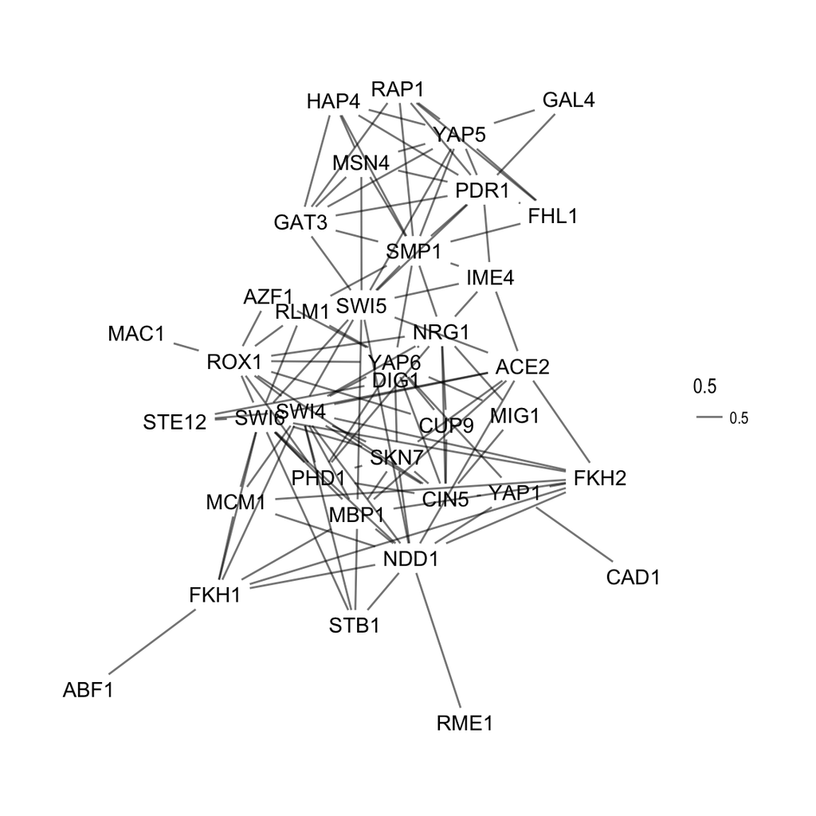

```r
ggraph(big.TF.TF, layout = "kk") +
  geom_node_text(aes(label=name)) +
  geom_edge_link(aes(start_cap = label_rect(node1.name),
                     end_cap = label_rect(node2.name),
                     edge_alpha = 0.5)) +
  theme_graph()
```

See the [ggraph github site](https://github.com/thomasp85/ggraph) and associated links for a more thorough introduction to using ggraph.

## Building a directed TF-TF network

```r
all.tfs <- unique(lee.tfs.long$TF)

tfs.only.wide <- filter(lee, Common.Name %in% all.tfs) %>% select(-Annotation,-Name)

tfs.only.long <- tfs.only.wide %>%
                 gather(TF, pvalue, -Common.Name )%>%
                 select(TF, Common.Name, pvalue) %>%
                 rename(target = Common.Name)
```

Now filter TF-TF network

```r
tfs.only.filtered <- tfs.only.long %>%
                     filter(pvalue < 0.001)

tfs.only.graph <- graph_from_data_frame(tfs.only.filtered, directed = TRUE)
```

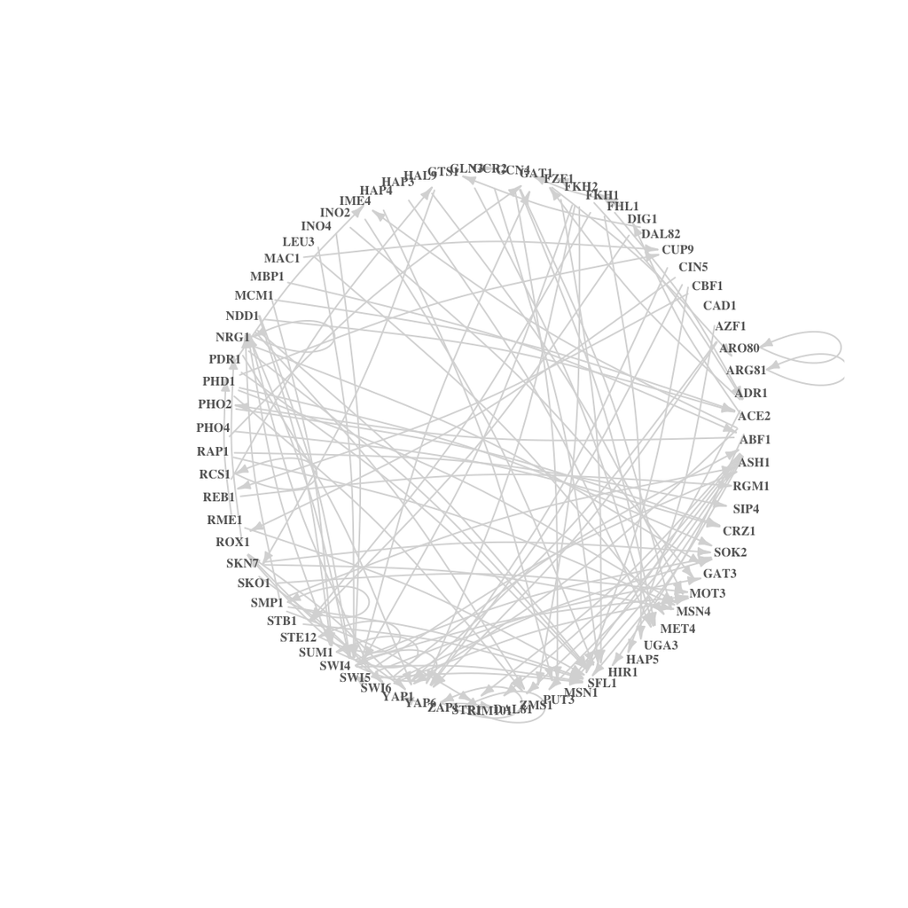

```r
l <- layout.circle(tfs.only.graph)

plot(tfs.only.graph, edge.arrow.size=.4, vertex.shape="none", vertex.label.cex=0.5, edge.curved=0.1, vertex.label.font=2, vertex.label.color="gray40", edge.color="gray85", layout=l)
```

## More network analysis resources for R

There’s an excellent tutorial on [Network Visualization in R](https://rpubs.com/kateto/netviz) (primarily based on igraph). Check it out for more ideas.

Once you’ve generated a network you might consider using another program to visualize the network.

[Pajek](http://mrvar.fdv.uni-lj.si/pajek/) is a popular windows program for network visualization (igraph can produce a Pajek formatted representation of a graph).